# Google Trends and Social Anxiety in Individualistic and Collectivistic countries

Kapelle Grigoria, Makavou Anna, Sigala Dimitra, Fragkiadaki Sotiria,

15 April 2019

## Individualistic countries;

Importance of personal expression and assertion

e.g. United Kindom

(Heinrichs et al. (2006), Hofmann, Anu Asnaani, and Hinton (2010))

## Collectivistic countries

Importance of group harmony maintenance

e.g. Chile

(Heinrichs et al. (2006), Hofmann, Anu Asnaani, and Hinton (2010))

## Introduction

Studies have shown that although collectivistic countries experience higher levels of social anxiety, its not obvious due to their belonging to a group. (Schreier et al. (2010))

Thus, we hypothesised that reports for social anxiety will appear to be more in individualistic countries despite the higher levels in collectivistic.

## Hypothesis

Google searches related to social anxiety, appear to be more in individualistic cultures than in collectivistics.

I.V. Type of society: Chile (collectivistic) and United Kingdom (individualistic)

D.V. google "hits" on terms related to social anxiety

## Methods

Downloaded data from google trends for social phobia (UK) and fobia social (CL)

Analyzed data

T-test analysis To compare the means of each countries' hits

## Data

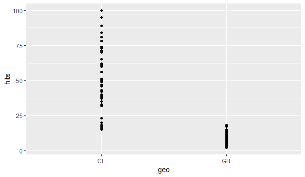

Google "hits" for Chile (CL) and UK (GB)

Chille "Fobia Social" UK "Social Phobia"

## Results

sample estimates: mean of CL mean of GB

42.53846 7.50000

t(53.471) = 12.068, p < 2.2e-16

Therefore, we know that there is significant difference between the means, but more hits appeared in Chile rathen than in UK

## Discussion

Our results opposed to our hypothesis. Specifically,

they confirmed that collectivistic countries experience higher levels of social anxiety, since their actions are being constantly evaluated by the members of the group (Heinrichs et al. (2006))

BUT they didn't confirm the fact that it's not apparent due to their belonging to group. (Schreier et al. (2010))

## Limitations/Future implications

1. Google Trends Analysis is less valid as a method on its own. A qualitative research would be needed as well
2. In the project we used one-level experimental groups: One Latin- American country for Collectivistic and one European for Individualistic.
3. We used one term related to social anxiety for each country (Fobia Social, Social Phobia). More terms could possibly increase the validity and reliability of the results (eg: Social Anxiety)

## References

Heinrichs, Nina, Ronald M. Rapee, Lynn A. Alden, Susan Maria Bögels, Stefan G. Hofmann, Kyung Ja Oh, and Yuji Sakano. 2006. “Cultural Differences in Perceived Social Norms and Social Anxiety.” *Behaviour Research and Therapy* 44 (8): 1187–97.

Hofmann, Stefan G., M.A. Anu Asnaani, and Devon E. Hinton. 2010. “Cultural Aspects in Social Anxiety and Social Anxiety Disorder.” *Depression and Anxiety* 27 (12): 1117–27. doi:10.1002/da.20759.

Schreier, Sina-Simone, Nina Heinrichs, Lynn Alden, Ronald M. Rapee, Stefan G. Hofmann, Junwen Chen, Kyung Ja Oh, and Susan Bögels. 2010. “Social Anxiety and Social Norms in Individualistic and Collectivistic Countries.” *Depression and Anxiety* 27 (12): 1128–34. doi:10.1002/da.20746.